# Качество государственной медицины глазами граждан

## Проверка региональной структуры (ICC)

Пустая модель $Quality_{ir} = \beta_0 + u_r + \epsilon_{ir}$ и $ICC = \sigma^2_{region} / (\sigma^2_{region} + \sigma^2_{individual})$.

Считаем тремя способами:

1. **Линейная модель со случайным интерсептом региона** (REML, `nlme::lme`) — прямая оценка формулы выше, оценка 1–10 как непрерывная.
2. **То же с фиксированными эффектами года** — годы отличаются по уровню оценок, и эта разница не должна попадать в региональную дисперсию; в 2021 году регионов 17, в 2022–2024 — 20.
3. **Порядковая модель** (`ordinal::clmm`) — та же спецификация, что мы используем для основных моделей: индивидуальная дисперсия латентной переменной фиксирована и равна π²/3.

```r
q_data <- filter(d, !is.na(q)) |> mutate(q_ord = factor(q, levels = 1:10, ordered = TRUE))

icc_lme <- function(fit) {
  vc <- suppressWarnings(as.numeric(VarCorr(fit)[, "Variance"]))
  c(tau2 = vc[1], sigma2 = vc[2], icc = vc[1] / (vc[1] + vc[2]))
}

lme0 <- lme(q ~ 1, random = ~ 1 | region, data = q_data, method = "REML")
lme_year <- lme(q ~ year_f, random = ~ 1 | region, data = q_data, method = "REML")

clmm_file <- file.path(out_dir, "icc_clmm0.rds")
if (!file.exists(clmm_file)) {
  clmm0 <- clmm(q_ord ~ 1 + (1 | region), data = q_data, link = "logit",
                control = clmm.control(method = "nlminb", iter.max = 2000, eval.max = 4000))
  saveRDS(clmm0, clmm_file)
}
clmm0 <- readRDS(clmm_file)
stopifnot(grepl("convergence", clmm0$optRes$message), clmm0$dims$nobs == nrow(q_data))
tau2_ord <- as.numeric(VarCorr(clmm0)$region)

by_year <- map(years, \(y) icc_lme(lme(q ~ 1, random = ~ 1 | region,
                                      data = filter(q_data, year == y), method = "REML")))

bind_rows(
  tibble(Модель = "Линейная, пустая (2021–2024)", N = nrow(q_data), Регионов = n_distinct(q_data$region),
         !!!as.list(icc_lme(lme0))),
  tibble(Модель = "Линейная + эффекты года", N = nrow(q_data), Регионов = n_distinct(q_data$region),
         !!!as.list(icc_lme(lme_year))),
  tibble(Модель = "Порядковая (clmm), пустая", N = nrow(q_data), Регионов = n_distinct(q_data$region),
         tau2 = tau2_ord, sigma2 = pi^2 / 3, icc = tau2_ord / (tau2_ord + pi^2 / 3)),
  map2(years, by_year, \(y, v) tibble(Модель = paste("Линейная, пустая,", y),
                                     N = sum(q_data$year == y),
                                     Регионов = n_distinct(q_data$region[q_data$year == y]),
                                     !!!as.list(v))) |> list_rbind()
) |>
  rename(`σ² региона` = tau2, `σ² индивид.` = sigma2, ICC = icc) |>
  knitr::kable(digits = 3)
```

| Модель | N | Регионов | σ² региона | σ² индивид. | ICC |
| --- | --- | --- | --- | --- | --- |
| Линейная, пустая (2021–2024) | 44507 | 20 | 0.277 | 3.564 | 0.072 |
| Линейная + эффекты года | 44507 | 20 | 0.255 | 3.524 | 0.067 |
| Порядковая (clmm), пустая | 44507 | 20 | 0.258 | 3.290 | 0.073 |
| Линейная, пустая, 2021 | 11641 | 17 | 0.259 | 3.859 | 0.063 |
| Линейная, пустая, 2022 | 10911 | 20 | 0.251 | 3.440 | 0.068 |
| Линейная, пустая, 2023 | 11029 | 20 | 0.329 | 3.455 | 0.087 |
| Линейная, пустая, 2024 | 10926 | 20 | 0.355 | 3.176 | 0.101 |

**Результат.**

- **ICC около 0.07**: примерно 7% различий в оценках приходится на различия между регионами, 93% — на различия между людьми внутри региона. Три способа расчёта дают одно и то же (0.072, 0.067 с эффектами года, 0.073 в порядковой модели).
- Это **не «практически ноль»**: региональная вариация заметна, и многоуровневая модель оправдана. Причём при ~2 200 респондентах на регион даже ICC 0.07 даёт эффект дизайна около 1 + 2 200 × 0.07 ≈ 155: без учёта группировки по регионам стандартные ошибки региональных показателей были бы занижены примерно в 12 раз. При этом основная часть вариации — индивидуальная.
- ICC **растёт от года к году** (0.063 в 2021 → 0.101 в 2024): региональные различия усиливаются.
- Групп всего 17–20, поэтому дисперсия региона оценивается неточно, а в моделях можно использовать лишь 1–2 региональных показателя.

Разброс регионов вокруг общего среднего (предсказанные случайные эффекты линейной модели с эффектами года) — показывает, какие регионы формируют межрегиональную дисперсию:

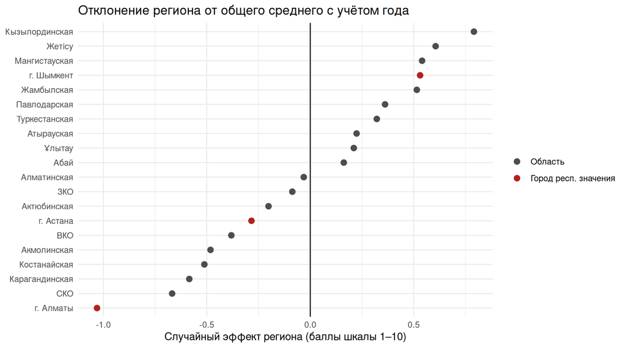

```r
re <- ranef(lme_year)
tibble(TE = rownames(re), effect = re[, 1]) |>
  mutate(region = region_names[TE], capital = TE %in% capitals) |>
  ggplot(aes(effect, fct_reorder(region, effect), colour = capital)) +
  geom_vline(xintercept = 0) +
  geom_point(size = 2.5) +
  scale_colour_manual(values = c(`FALSE` = "grey30", `TRUE` = "firebrick"),
                      labels = c("Область", "Город респ. значения")) +
  labs(x = "Случайный эффект региона (баллы шкалы 1–10)", y = NULL, colour = NULL,
       title = "Отклонение региона от общего среднего с учётом года")
```

**Результат.** Картина та же, что на карте: самые низкие оценки при прочих равных у Алматы (около −1 балла от среднего), СКО, Карагандинской, Костанайской и Акмолинской областей; самые высокие — у Кызылординской, Жетісу, Мангистауской, Шымкента и Жамбылской. Астана — ниже среднего, Шымкент — выше: «эффект столиц» касается прежде всего Алматы и Астаны.

## Выводы и следующий шаг

1. **Оценка качества государственной медицины пригодна для порядковой модели**: пропусков 2–4%, «эффекта потолка» нет. Оценки растут от года к году, поэтому эффекты года обязательны.
2. **Доступность почти дублирует качество** (одинаковый балл у двух третей респондентов) — в основной модели мы её не используем.
3. **Социальные различия.** Сильнее всего оценка связана с удовлетворённостью здоровьем, затем с материальным положением (выше только у обеспеченных) и типом населённого пункта (на селе выше). Возраст и образование почти не важны.
4. **Материальное положение анализируем с учётом года**: группа «ниже среднего» почти вся из 2021 года, а сама связь с оценкой усиливается в 2023 году вместе с изменением структуры данных.
5. **Неудовлетворённая потребность почти одинакова во всех группах (12–14%)** и не связана со здоровьем; устойчиво с ней связано только ухудшение материального положения. Среди причин главные — самолечение и организационные барьеры (нет специалиста, очереди); удалённость и отсутствие лекарств встречаются редко.
6. **Региональная вариация есть (ICC ≈ 0.07) и растёт**, многоуровневая модель оправдана. Но связь региональных ресурсов с оценками определяется Астаной и Алматы, а регионов всего 20.

**Следующий шаг — модели.** Индивидуальные факторы (материальное положение, здоровье, опыт получения помощи, барьеры) мы оцениваем порядковой моделью с эффектами года и региона. Роль регионального контекста — многоуровневой порядковой моделью с одним показателем ресурсов (или их индексом), с отдельным учётом городов республиканского значения и проверкой устойчивости без них.